# Day 7 - Bag of Words Clustering

Bryan Goodrich

January 7, 2017

# Motivation

I saw a good demonstration on my Feedly about bag-of-words stuff.

http://ellisp.github.io/blog/2016/12/31/sparse-bags

I’ve done topic modeling on Twitter queries. I figured I could get some more experience. Here we just do the first part of what the author did, which focuses on doing k-means clustering of the document-term matrix (DTM). It’s a sparse matrix as each document only has a small portion of the entire vocabulary used in the corpus. There are a number of reasons k-means will not do that great at this, but it may still be a quick-and-dirty way to get at something. So why not try it out and see?

### Data

https://archive.ics.uci.edu/ml/datasets/Bag+of+Words

The data is available from the UCI machine learning data sets. You can get it yourself. See below for the author’s methods for getting at the data directly.

If you’d like to get the data directly from the sources, here is the author’s code for that.

```r
# https://archive.ics.uci.edu/ml/datasets/Bag+of+Words
# download the smallest example bag of words for first trial
if(!"docword.kos.txt" %in% list.files())
{
    data_file <- "https://archive.ics.uci.edu/ml/machine-learning-databases/bag-of-words/docword.kos.txt.gz"
    download.file(data_file, destfile = "docword.kos.txt.gz", mode = "wb")
    gunzip("docword.kos.txt.gz")
}
kos_header <- c("DocId", "VocabId", "Count")
x <- read.table("docword.kos.txt", skip = 3, col.names = kos_header)
vocab <- read.table("https://archive.ics.uci.edu/ml/machine-learning-databases/bag-of-words/vocab.kos.txt")$V1
```

I work from my own file structure, so I’ll just assume you can get the data in how you want to follow along with my code below.

Here I pull in the bag of words structured data (see the UCI documentation), the vocab associated with it (each line represents the line number in the UCI file)

```r
kos_header <- c("DocId", "VocabId", "Count")
vocab <- scan("data/vocab.kos.txt", what = "")
x <- read.table("data/docword.kos.txt", skip = 3, col.names = kos_header)
x$Word <- vocab[x$VocabId]
x$Word <- wordStem(x$Word)

x <- x %>% group_by(DocId, Word) %>% summarise(Count = sum(Count))    # Dense
y <- reshape2::dcast(x, DocId ~ Word, value.var = "Count", fill = 0)  # Sparse DTM
y$DocId <- NULL  # Column not needed; each row is its DocId
```

```r
kc <- stepFlexclust(y, 2:10, FUN = cclust, seed = 2017, multicore = TRUE)
saveRDS(kc, file = 'data/kos_models.Rds', compress='xz')
```

# Wordcloud

While a more in-depth analysis of the resultant models to find the ‘best’ one using internal and external validation methods, I’m just going to pick k=5 and run with it!

If you’ve not used *flexclust* the `parameters` function lets you access the cluster centroids of your model object. See also the `info` function that you can use to access key information, such as distance measures and cluster sizes.

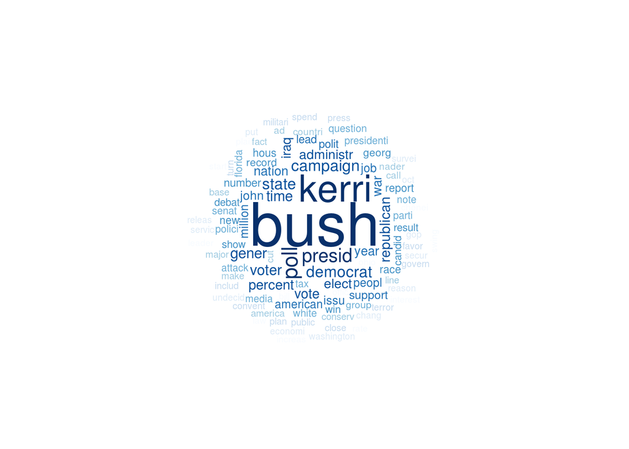

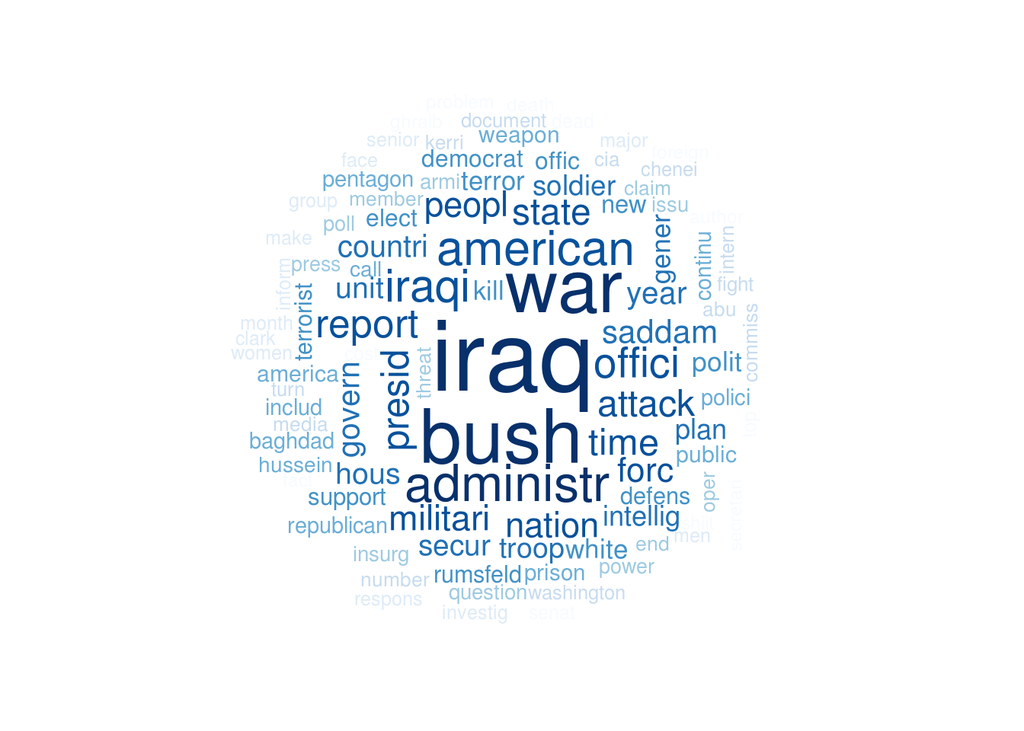

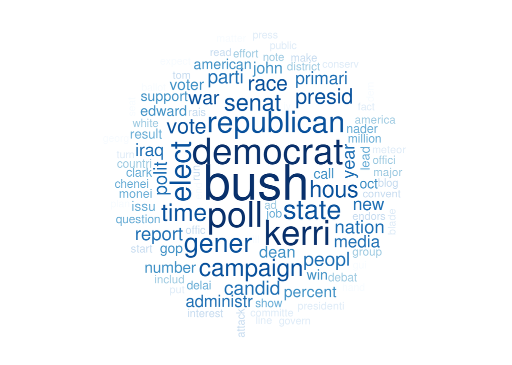

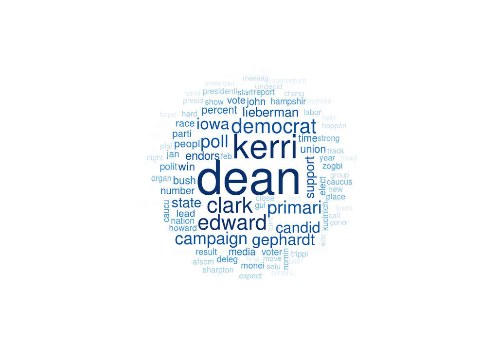

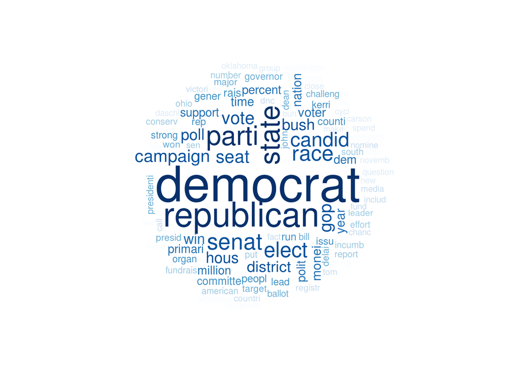

```r
# A convenience closure
topN <- function(N) function(k, model) head(sort(parameters(model)[k, ], TRUE), n = N)

kc <- readRDS("data/kos_models.Rds")
k <- 5  # The k sized model to use in this example
h <- 100 # how many top words to put in the cloud
p <- lapply(1:k, topN(100), model = getModel(kc, k))

pal <- rep(brewer.pal(9, "Blues"), each = ceiling(h / 9))[h:1]
for (n in 1:k)
{
    wordcloud(
        names(p[[n]]), freq = p[[n]], min.freq=0, random.order = FALSE,
        ordered.colors = TRUE, colors = pal
    )
}
```

# Concluding Comments

I don’t want to say we actually latched onto some meaningful content, and we certainly haven’t dug into the data to really valdiate the results. Nevertheless, we can clearly see in this model, which has a good spread of cluster sizes (not shown here), that there are some clear differences in the most frequent words.

This could be improved by using normalized data instead of raw counts. I wouldn’t mind trying this on H20 or any distributed system to test that out. Nevertheless, I think an LDA topic modeling approach will just be a better option (but does it scale? is it as easy to knock out?)